# Covid Data Exploration

Madeleine Guettler

2023-04-19

# Introduction

This time series exploration focuses on daily confirmed covid cases in Singapore collected by Hui Xiang Chua.For the exploration I focused on daily data from January 23, 2020 to January 23, 2022. Throughout this project I attempted to fit daily confirmed covid case ARIMA models, monthly average confirmed covide case ARIMA models, and finally a light exploration of Regime Switching Models.

# Packages and Dataset to Download

```r
library(readr)
library(tseries)
library(forecast)
```

```r
library(readxl)
Covid19 <- read_csv("Covid-19 SG.csv")
```

```
## ──────────────────────────────────────────────────────── Delimiter: "," chr
## (4): Phase, Perc population completed at least one dose, Perc populati... dbl
## (31): Daily Confirmed, False Positives Found, Cumulative Confirmed, Dai... lgl
## (1): ...37 date (1): Date
```

```r
Covid19 <- Covid19[-38,]
```

# Time Series Daily Confirmed

First let’s create a time series containing daily confirmed cases from Jan 23, 2020 to Jan 23, 2022. And see how our data looks.

```r
covid_confirmed_ts <- ts(Covid19[,2], start = c(2020, 23), end = c(2022, 23), frequency = 365)
```

# Plot

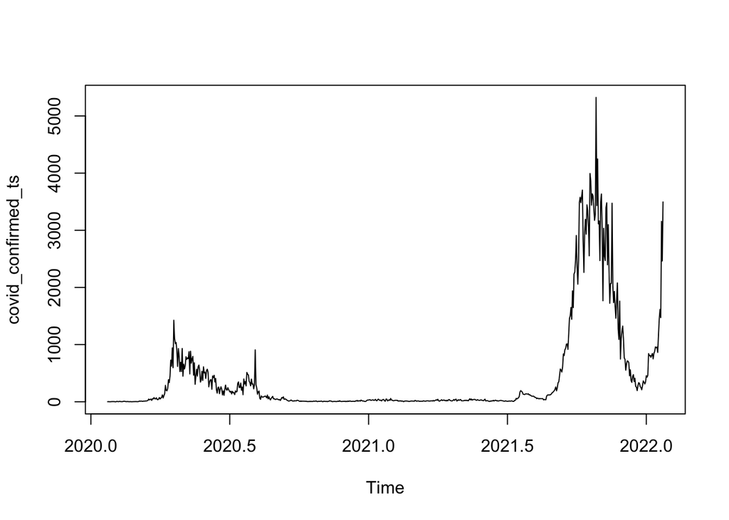

```r
plot(covid_confirmed_ts)
```

```r
covid_confirmed_ts
```

```
## Time Series:
## Start = c(2020, 23)
## End = c(2022, 23)
## Frequency = 365
##   [1]    1    2    1    0    1    2    3    3    3    2    0    0    6    4    2
##  [16]    3    7    3    2    2    3    8    9    5    3    2    4    3    1    1
##  [31]    3    0    1    1    2    3    2    4    2    2    2    5   13    8   12
##  [46]   10    6   12    9   13   12   14   17   23   47   32   40   47   23   54
##  [61]   49   73   52   49   70   42   35   47   74   49   65   75  120   66  106
##  [76]  142  287  198  191  233  386  334  447  728  623  942  596 1426 1111 1016
##  [91] 1037  897  618  931  799  528  690  528  932  447  657  573  632  788  741
## [106]  768  753  876  486  884  675  752  793  465  682  305  451  570  448  614
## [121]  642  548  344  383  533  373  611  506  518  408  544  569  517  261  344
## [136]  383  386  218  451  422  463  347  407  214  151  247  257  142  218  262
## [151]  218  119  191  113  219  291  213  202  246  215  188  169  185  136  183
```

[output cut: 38 more lines]

Generally it looks like we see the initial spike when covid started and as restrictions increased Singapore went through a fairly stable period. In looking at Singapore guidelines around mid of 2021 restriction protocols started to ease which potentially could explain the spike in cases. There also seems to be a pattern of spikes in the mid point of 2020 and 2021.

# Decomposition

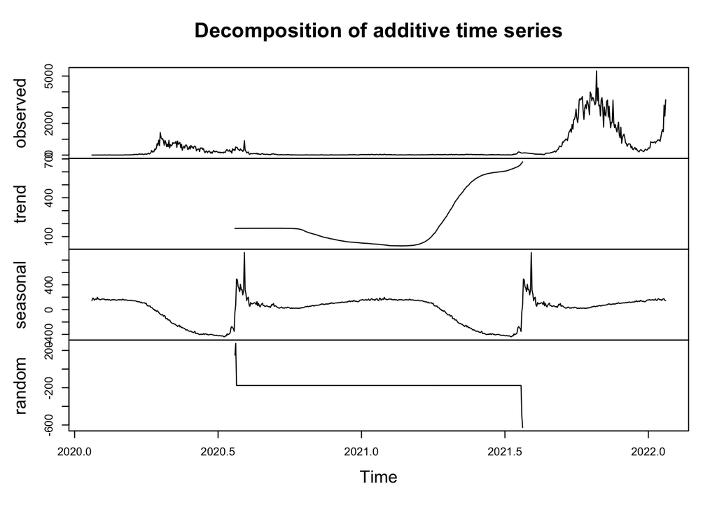

```r
covid_confirmed_ts.decom = decompose(covid_confirmed_ts)
plot(covid_confirmed_ts.decom)
```

Top: Actual observed data would be the same as `plot(co2)` Second: Trend- overall direction of data Third: Seasonality- pattern. How much we’re going up and down from our trend Fourth: Measurement error, uncertainty

# ADF and ACF plot

```r
adf.test(covid_confirmed_ts)
```

```
##
##  Augmented Dickey-Fuller Test
##
## data:  covid_confirmed_ts
## Dickey-Fuller = -1.9171, Lag order = 9, p-value = 0.6134
## alternative hypothesis: stationary
```

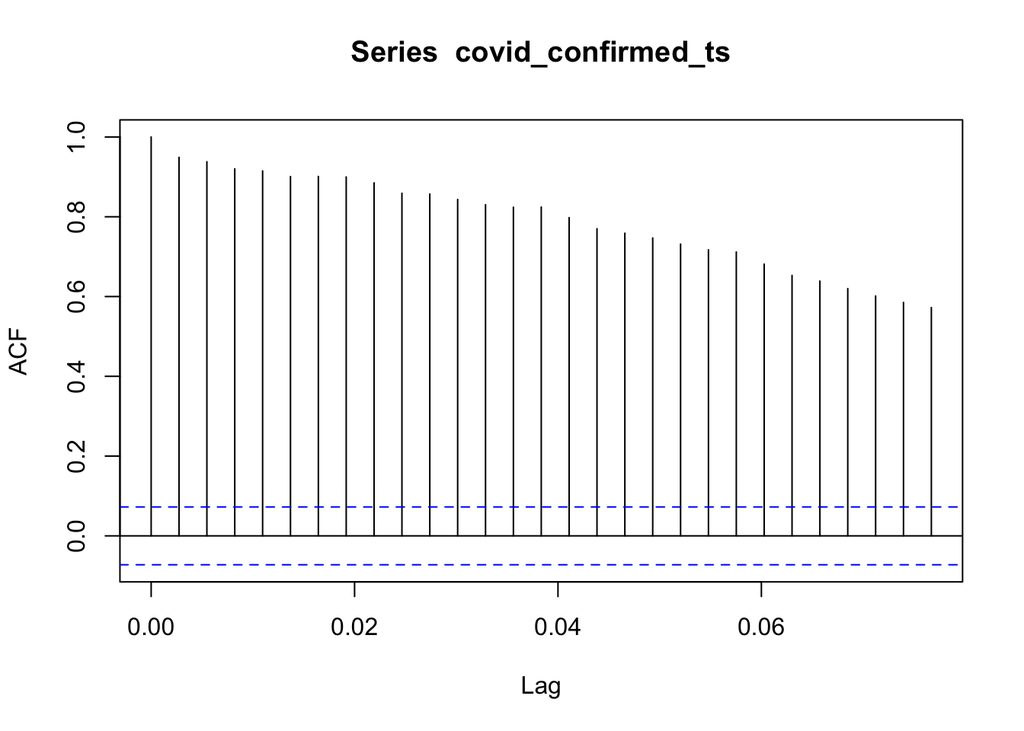

```r
acf(covid_confirmed_ts)
```

```r
adf.test(covid_confirmed_ts)
```

```
##
##  Augmented Dickey-Fuller Test
##
## data:  covid_confirmed_ts
## Dickey-Fuller = -1.9171, Lag order = 9, p-value = 0.6134
## alternative hypothesis: stationary
```

It does not seem like this model is stationary in anyway as we are far from seeing lags within the boundaries or any sign of exponential decay. Because of this we will try to make model stationary by differencing and also performing a log function as there appears to be variance in our data.

# Differencing

```r
covid_diff = diff(covid_confirmed_ts)
covid_diff365 = diff(covid_diff, 365)
```

```r
covid_19 = covid_confirmed_ts + 0.00001
covid_diff = diff(log(covid_19))
```

**Note** We have added 0.00001 to each observation in our data to avoid accidentally creating NA values when perform the log function on data and also difference the data.

# Acf/pacf plot

Let’s look at our ACF and PACF plots again to see if our plots are stationary now.

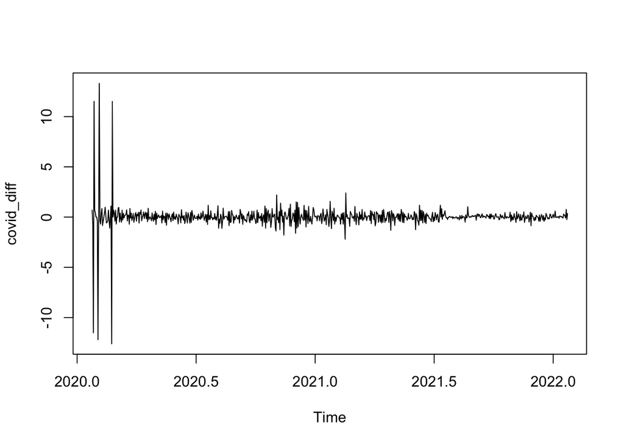

```r
plot(covid_diff)
```

```r
adf.test(covid_diff)
```

```
##
##  Augmented Dickey-Fuller Test
##
## data:  covid_diff
## Dickey-Fuller = -11.71, Lag order = 8, p-value = 0.01
## alternative hypothesis: stationary
```

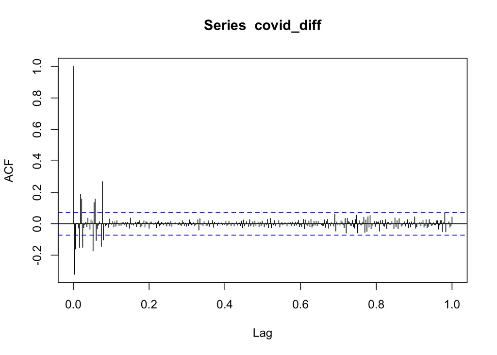

```r
acf(covid_diff, lag.max = 365)
```

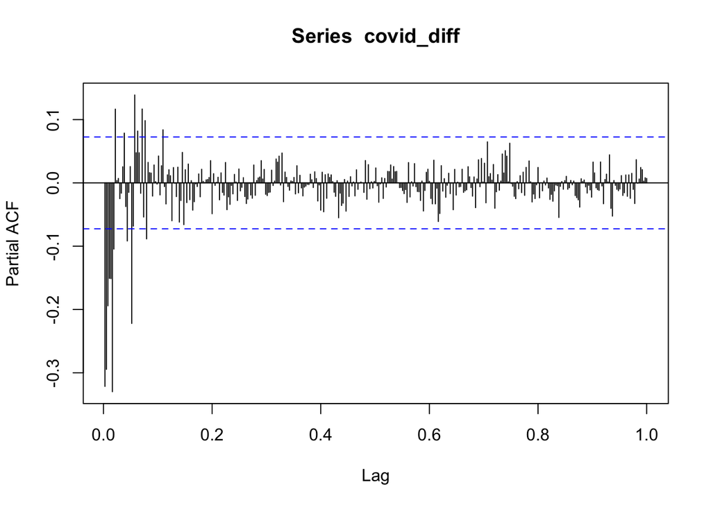

```r
pacf(covid_diff, lag.max = 365)
```

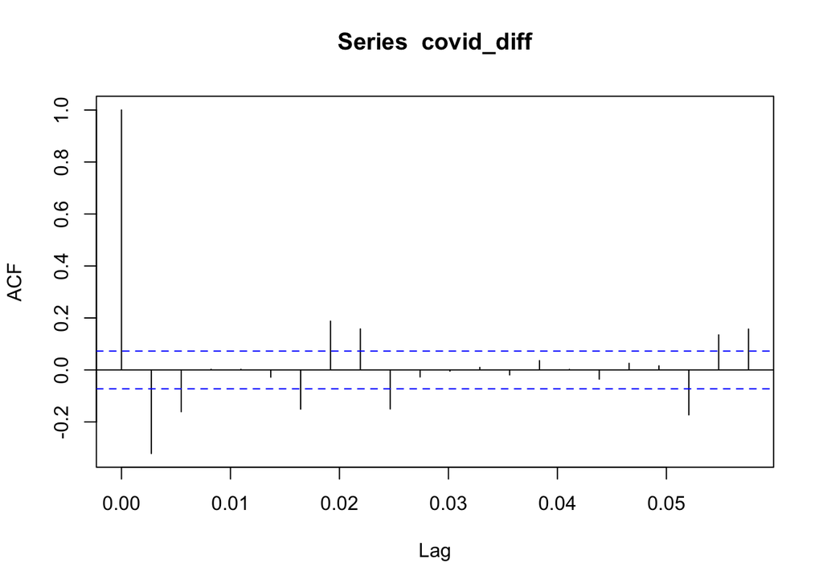

```r
acf(covid_diff, lag.max = 21)
```

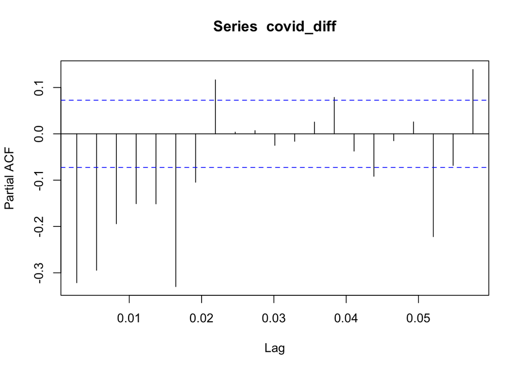

```r
pacf(covid_diff, lag.max = 21)
```

```r
auto.arima(covid_diff)
```

```
## Series: covid_diff
## ARIMA(5,0,2) with zero mean
##
## Coefficients:
##          ar1      ar2      ar3      ar4      ar5      ma1     ma2
##       0.9184  -0.4609  -0.0515  -0.1442  -0.1030  -1.5334  0.8097
## s.e.  0.1037   0.0565   0.0555   0.0562   0.0499   0.0966  0.0846
##
## sigma^2 = 0.9914:  log likelihood = -1029.9
## AIC=2075.8   AICc=2076   BIC=2112.55
```

```r
auto.arima(covid_confirmed_ts)
```

```
## Series: covid_confirmed_ts
## ARIMA(5,1,4)
##
## Coefficients:
##          ar1      ar2      ar3      ar4      ar5      ma1     ma2      ma3
##       0.1626  -0.9602  -0.1373  -0.4789  -0.5733  -0.7013  1.2458  -0.5555
## s.e.  0.0552   0.0383   0.0647   0.0299   0.0384   0.0682  0.0566   0.0619
##          ma4
##       0.7151
## s.e.  0.0332
##
## sigma^2 = 36091:  log likelihood = -4862.87
## AIC=9745.74   AICc=9746.05   BIC=9791.67
```

# Forecasting

The following function allows us to calculate a bias correct AIC value.

```r
AIC.to.AICC <- function (aic, n, pq1) {
  aic - 2 * pq1 + 2 * n * pq1 / (n - 1 - pq1) }
```

```r
auto.arima(covid_confirmed_ts)
```

```
## Series: covid_confirmed_ts
## ARIMA(5,1,4)
##
## Coefficients:
##          ar1      ar2      ar3      ar4      ar5      ma1     ma2      ma3
##       0.1626  -0.9602  -0.1373  -0.4789  -0.5733  -0.7013  1.2458  -0.5555
## s.e.  0.0552   0.0383   0.0647   0.0299   0.0384   0.0682  0.0566   0.0619
##          ma4
##       0.7151
## s.e.  0.0332
##
## sigma^2 = 36091:  log likelihood = -4862.87
## AIC=9745.74   AICc=9746.05   BIC=9791.67
```

```r
m3 = arima(covid_confirmed_ts, order = c(7,1,2), include.mean = F)
m4 = arima(covid_confirmed_ts, order = c(5,1,4), include.mean = F)

m3$aic
```

```
## [1] 9784.836
```

```r
m4$aic
```

```
## [1] 9745.744
```

```r
AIC.to.AICC(m3$aic, 730, 10)
```

```
## [1] 9785.142
```

```r
AIC.to.AICC(m4$aic, 730, 10)
```

```
## [1] 9746.05
```

In the case of these two models generated using the original undifferenced and logged data, the best performing model seems to be the model suggested by `auto.arima()`.

# Further exploration into how well model fits

Now that we have our models let’s see how well the model fits by looking at how normal our distributions are. We will look at several tests. First we will look at the histograms of both our ARIMA models.

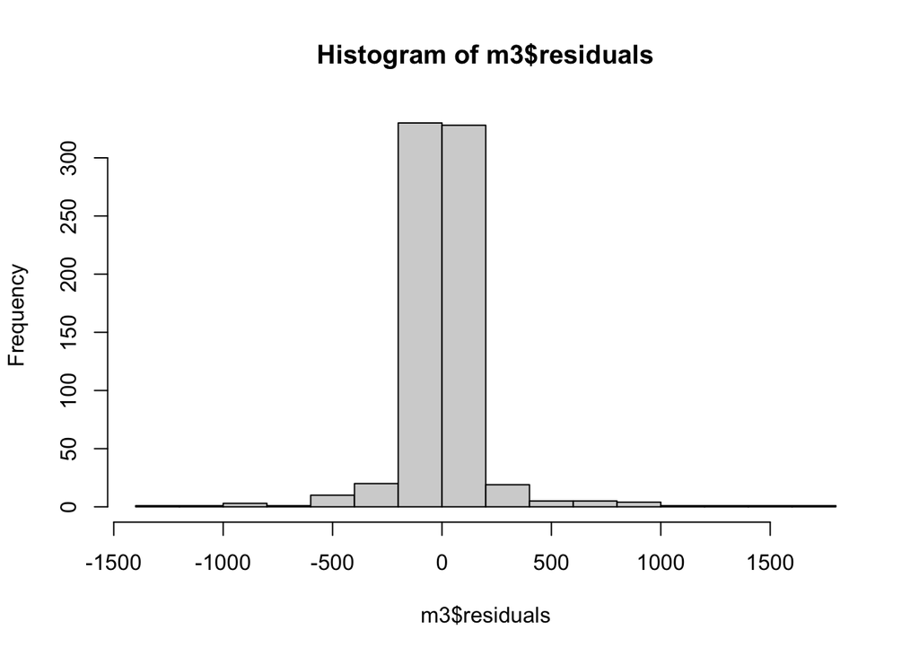

```r
hist(m3$residuals)
```

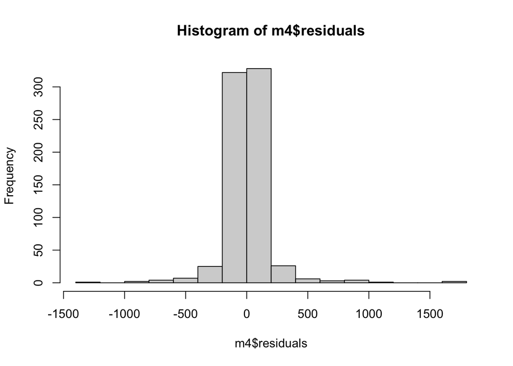

```r
hist(m4$residuals)
```

# Plots of residuals

Let’s look at our ACF and PACF models for the residuals.

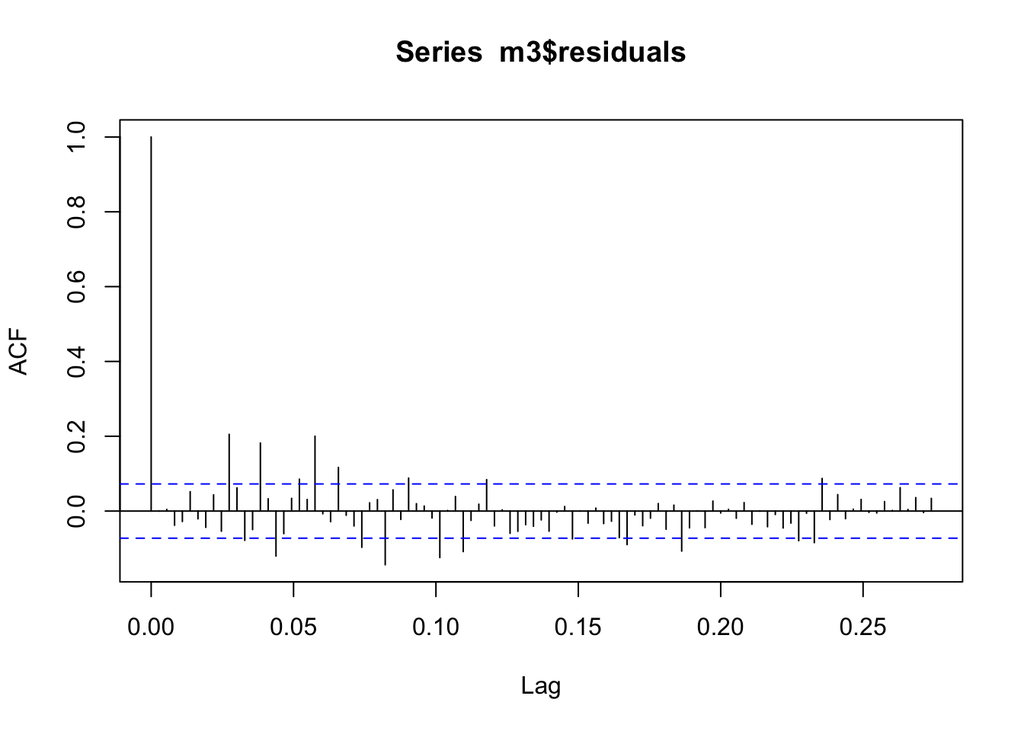

```r
acf(m3$residuals, lag.max = 100)
```

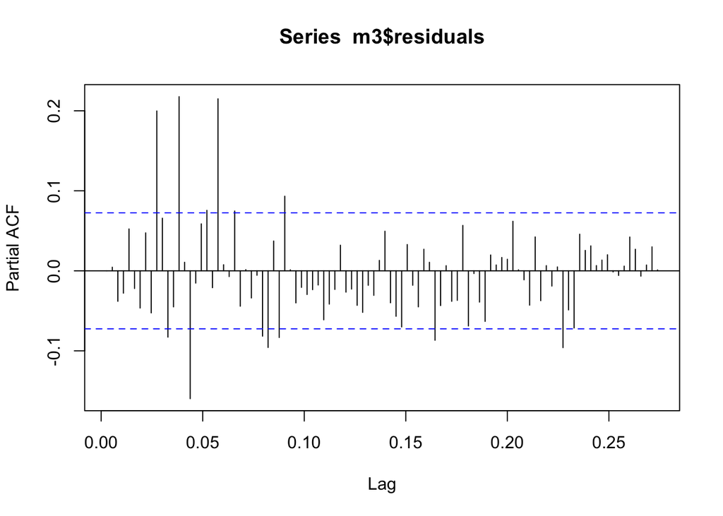

```r
pacf(m3$residuals, lag.max = 100)
```

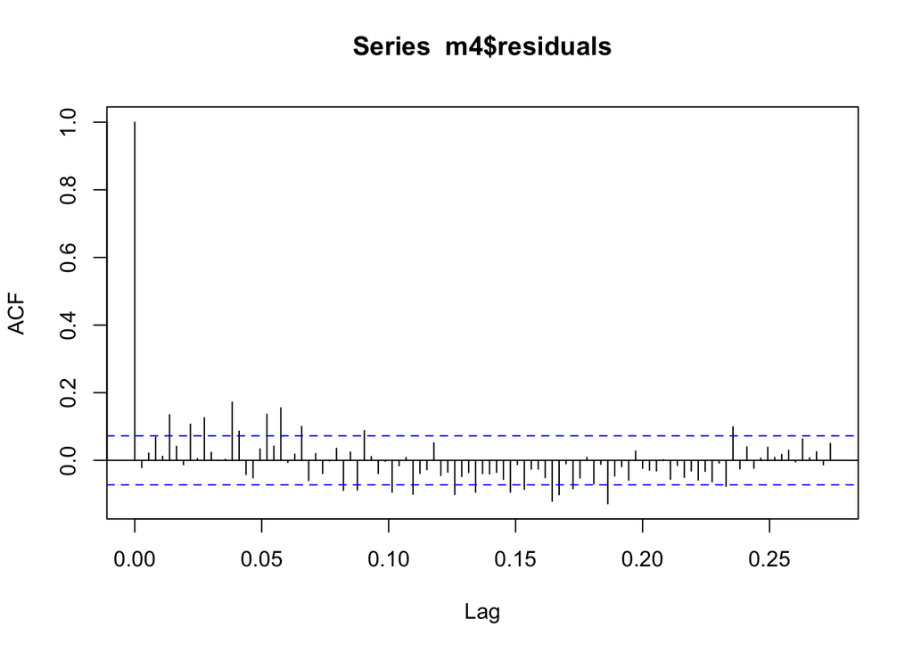

```r
acf(m4$residuals, lag.max = 100)
```

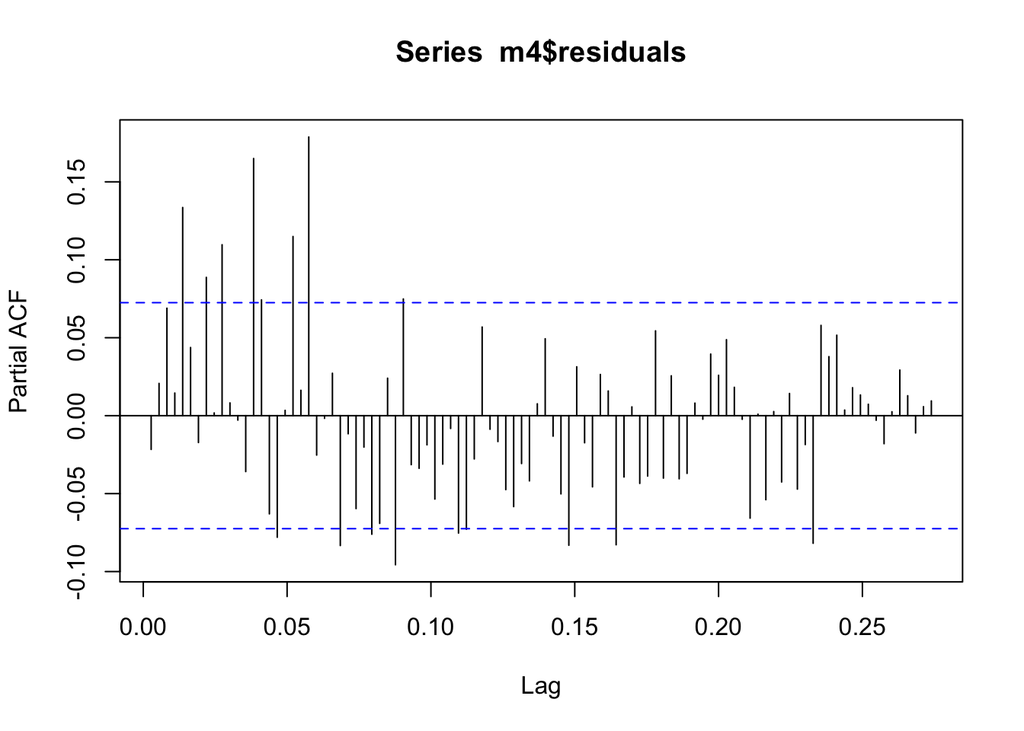

```r
pacf(m4$residuals, lag.max = 100)
```

Both models have issues of spikes that do not allow us to conclude that we have white noise in our models.

#Shapiro-Wilk Normality Test Another test we can do is the Shapiro-Wilk Normality Test. If we have a p-value less than 0.05 we are able to reject our null hypothesis that our models are normally distributed and instead conclude the alternative hypothesis that not normally distributed.

```r
shapiro.test(m3$residuals)
```

```
##
##  Shapiro-Wilk normality test
##
## data:  m3$residuals
## W = 0.5916, p-value < 2.2e-16
```

```r
shapiro.test(m4$residuals)
```

```
##
##  Shapiro-Wilk normality test
##
## data:  m4$residuals
## W = 0.60356, p-value < 2.2e-16
```

With both models at 5% significance level having shapiro wilk p-values less then 0.05, we are able to reject our null hypothesis and instead conclude that the data doesn’t come a normally distributed population.

#Ljung-Box Test The Ljung-Box test also allows us to assess lack of fit. Where our null hypothesis is that there is no lack of fit while our alternative hypothesis is that there is a lack of fit.

```r
Box.test(m3$residuals, lag = 30, type = "Ljung-Box")
```

```
##
##  Box-Ljung test
##
## data:  m3$residuals
## X-squared = 162.16, df = 30, p-value < 2.2e-16
```

```r
Box.test(m4$residuals, lag = 30, type = "Ljung-Box")
```

```
##
##  Box-Ljung test
##
## data:  m4$residuals
## X-squared = 124.12, df = 30, p-value = 2.065e-13
```

With p-values still less than 0.05, at the 5% significance level, we are able to conclude that there is a lack of fit.

#qqnorm plots The last test we can perform are qqnorm plots where we want out points and line to be as in line as possible.

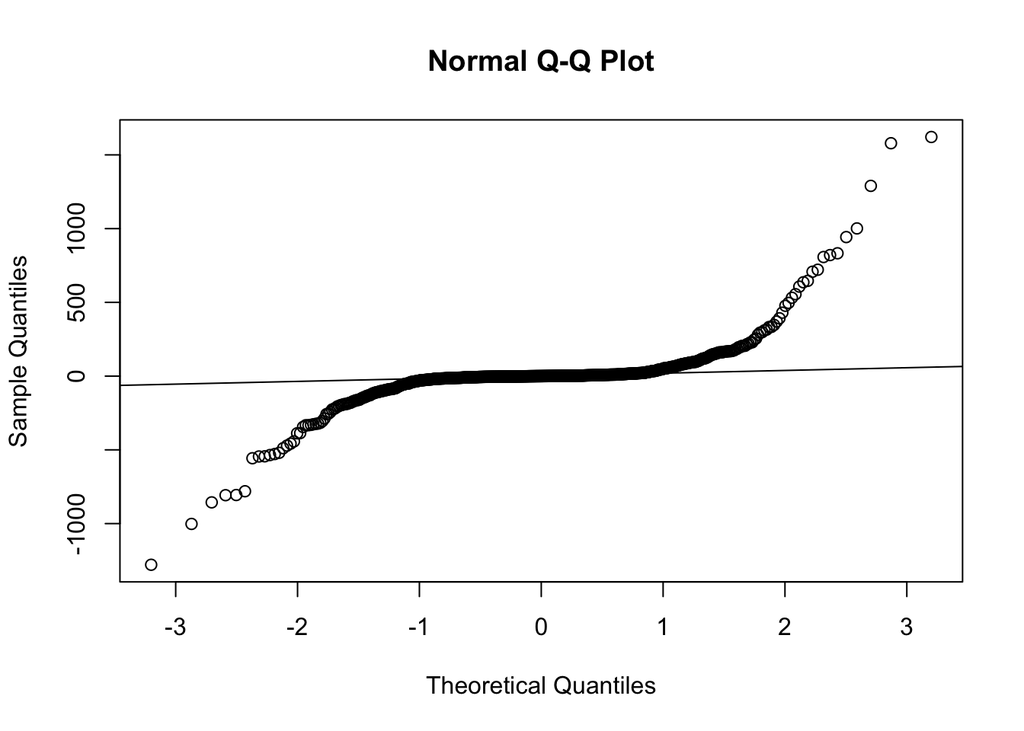

```r
qqnorm(m3$residuals)
qqline(m3$residuals)
```

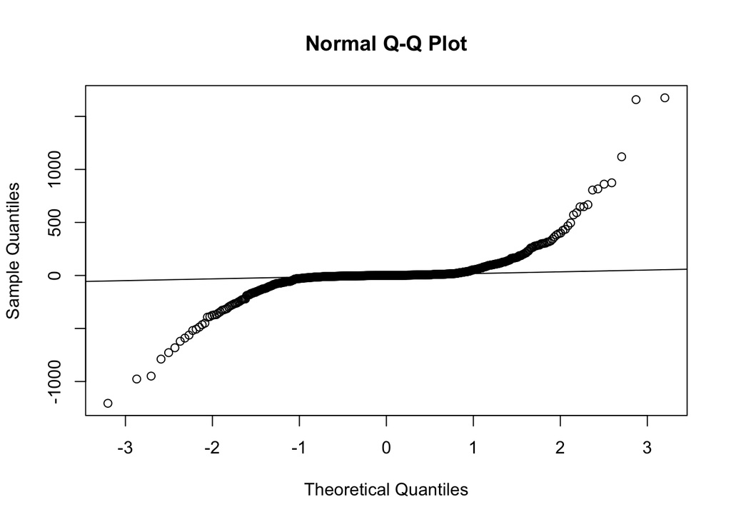

```r
qqnorm(m4$residuals)
qqline(m4$residuals)
```

# Averaged Data

Now let’s look at how successful we are with creating models if we explore averaged monthly confirmed covid cases.

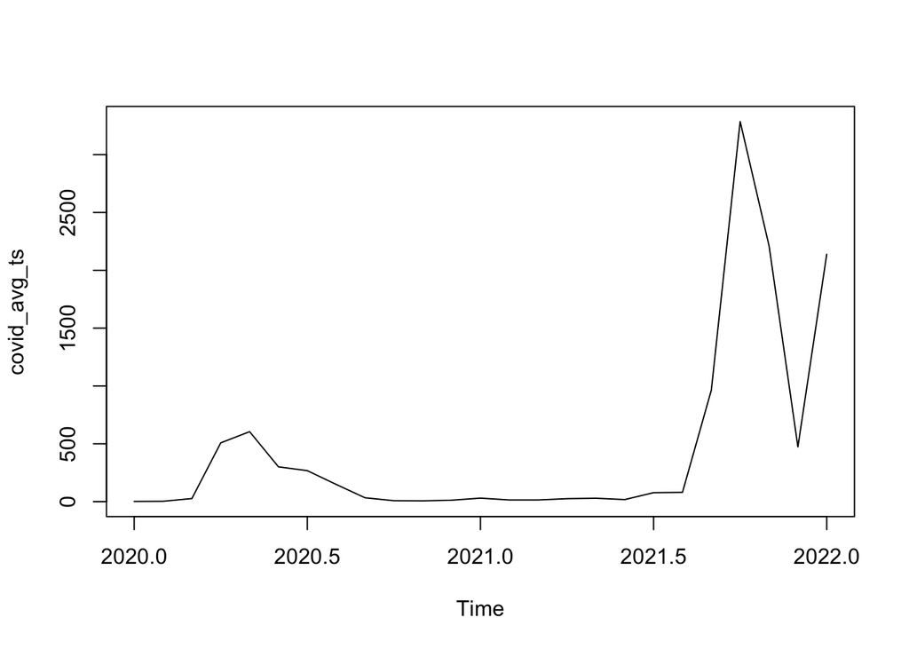

```r
library(readxl)
Covid19_avg <- read_excel("Covid19_avg.xlsx")

covid_avg_ts <- ts(Covid19_avg[,4], start = c(2020, 1), end = c(2022, 1), frequency = 12)
plot(covid_avg_ts)
```

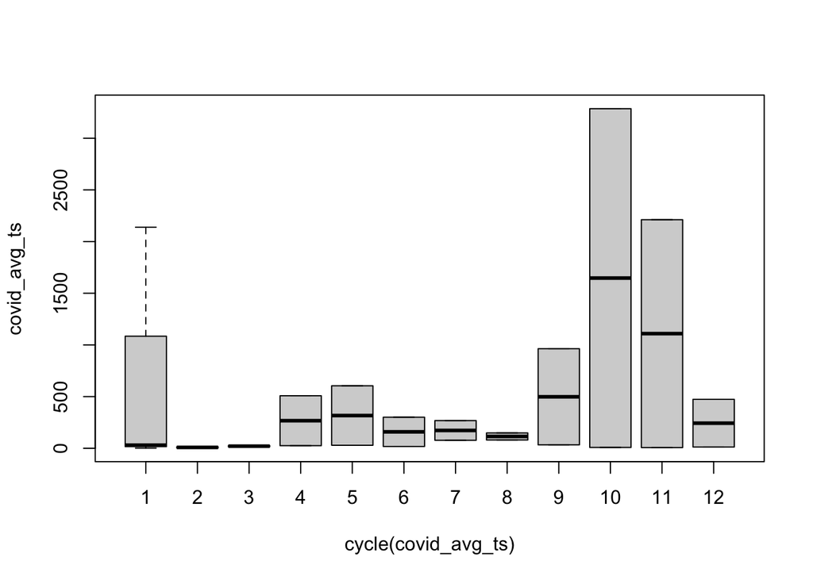

```r
boxplot(covid_avg_ts ~ cycle(covid_avg_ts))
```

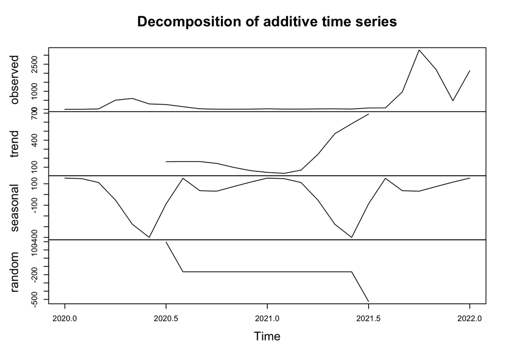

```r
plot(decompose(covid_avg_ts))
```

```r
adf.test(covid_avg_ts)
```

```
##
##  Augmented Dickey-Fuller Test
##
## data:  covid_avg_ts
## Dickey-Fuller = -0.027872, Lag order = 2, p-value = 0.99
## alternative hypothesis: stationary
```

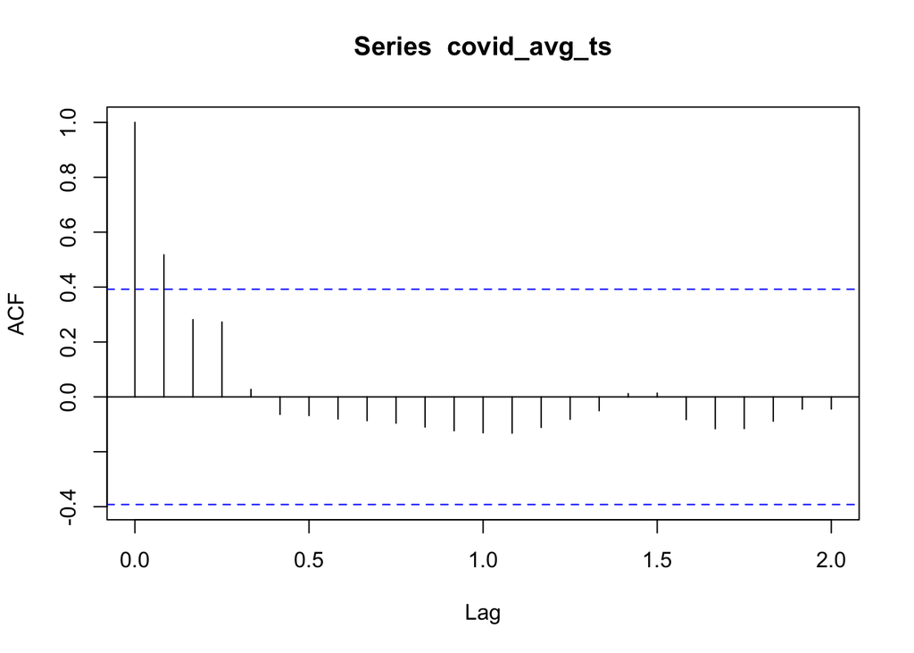

```r
acf(covid_avg_ts, lag.max = 24)
```

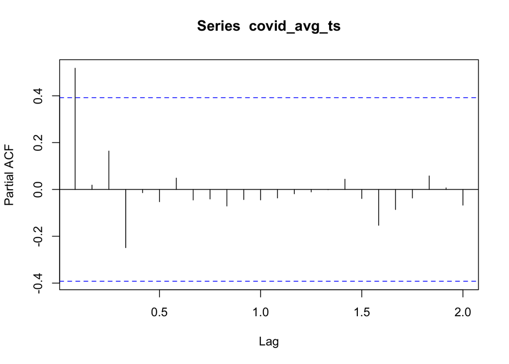

```r
pacf(covid_avg_ts, lag.max = 24)
```

```r
auto.arima(covid_avg_ts)
```

```
## Series: covid_avg_ts
## ARIMA(0,1,0)
##
## sigma^2 = 561986:  log likelihood = -192.93
## AIC=387.85   AICc=388.03   BIC=389.03
```

# Fitting ARIMA model

```r
avg1 = arima(covid_avg_ts, order = c(1,0,1), include.mean = F)
avg2 = arima(covid_avg_ts, order = c(0,1,0), include.mean = F)

#Compare models
avg1$aic
```

```
## [1] 398.0127
```

```r
avg2$aic
```

```
## [1] 387.8506
```

```r
AIC.to.AICC(avg1$aic, 25,3)
```

```
## [1] 399.1556
```

```r
AIC.to.AICC(avg2$aic, 25,2)
```

```
## [1] 388.3961
```

A way to see which model is the better fitting model we can compare our model’s Akaike Information criteria (AIC) and bias corrected AIC values to see which model was better. Because our second model has the lower AIC and AICC values the ARIMA(0,1,0) seems to be the better fitting model.

# Residual examination

Let’s still look at how our residual distributions look.

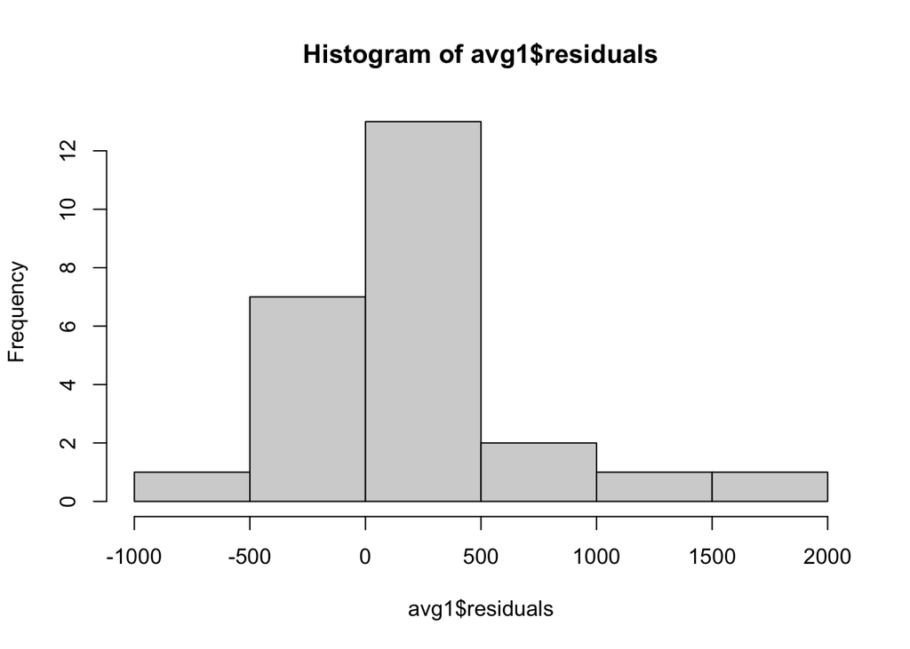

```r
hist(avg1$residuals)
```

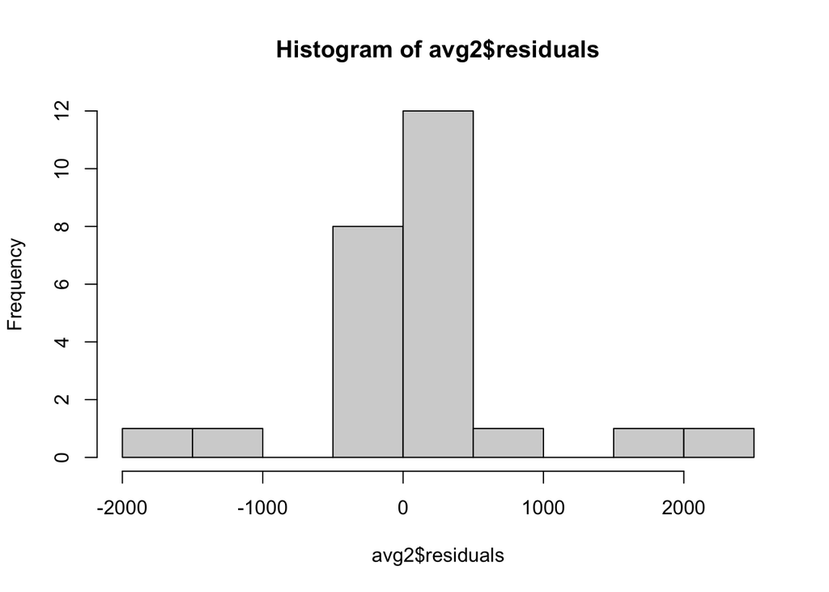

```r
hist(avg2$residuals)
```

Our ARIMA(1,0,1) model looks right skewed here so not quite normally distributed. Similarly our model that was suggested by `auto.arima` also does not look normally distributed.

#Shaprio-Wilks Test

```r
shapiro.test(avg1$residuals)
```

```
##
##  Shapiro-Wilk normality test
##
## data:  avg1$residuals
## W = 0.69166, p-value = 5.64e-06
```

```r
shapiro.test(avg2$residuals)
```

```
##
##  Shapiro-Wilk normality test
##
## data:  avg2$residuals
## W = 0.74197, p-value = 2.826e-05
```

# Ljung-Box Test

```r
Box.test(avg1$residuals, lag = 20, type = "Ljung-Box")
```

```
##
##  Box-Ljung test
##
## data:  avg1$residuals
## X-squared = 10.401, df = 20, p-value = 0.9603
```

```r
Box.test(avg2$residuals, lag = 20, type = "Ljung-Box")
```

```
##
##  Box-Ljung test
##
## data:  avg2$residuals
## X-squared = 12.824, df = 20, p-value = 0.8848
```

At the 5% significance level, with a p-value of 0.9603 for our ARIMA(1,0,1) model, we are unable to reject our null hypothesis that the data is independently distributed. Similarly with a p-value of 0.8848 for our ARIMA(0,1,0) model, we are unable to reject our null hypothesis that the data is independently distributed.

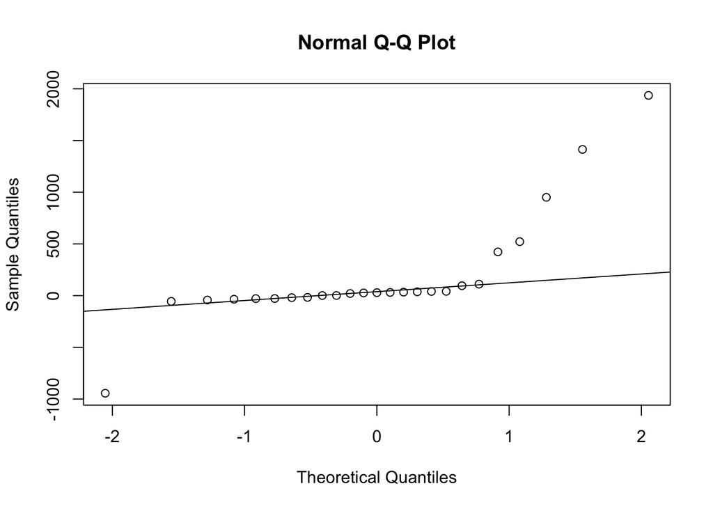

```r
qqnorm(avg1$residuals)
qqline(avg1$residuals)
```

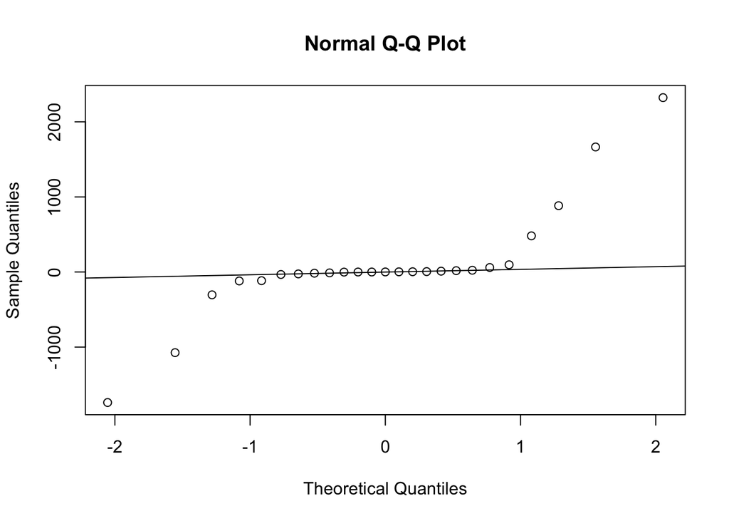

```r
qqnorm(avg2$residuals)
qqline(avg2$residuals)
```

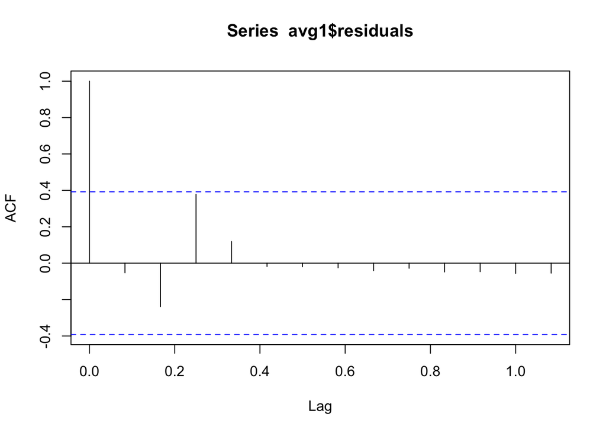

```r
acf(avg1$residuals)
```

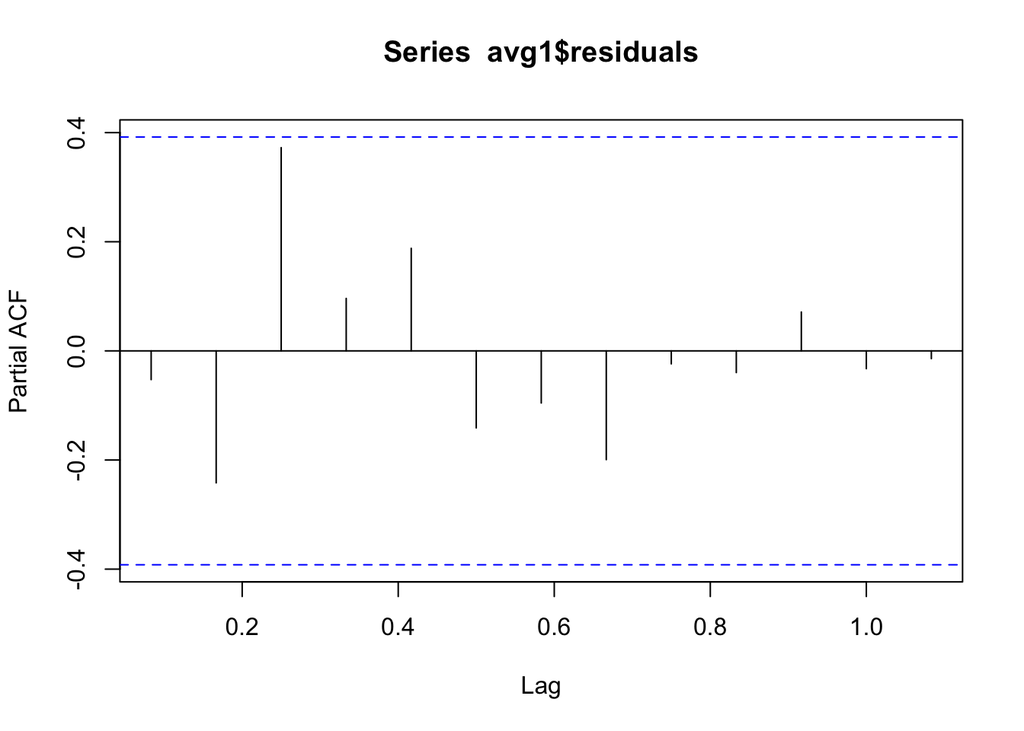

```r
pacf(avg1$residuals)
```

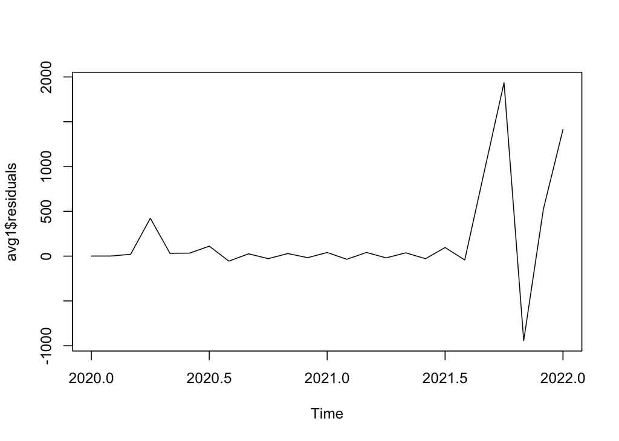

```r
plot(avg1$residuals)
```

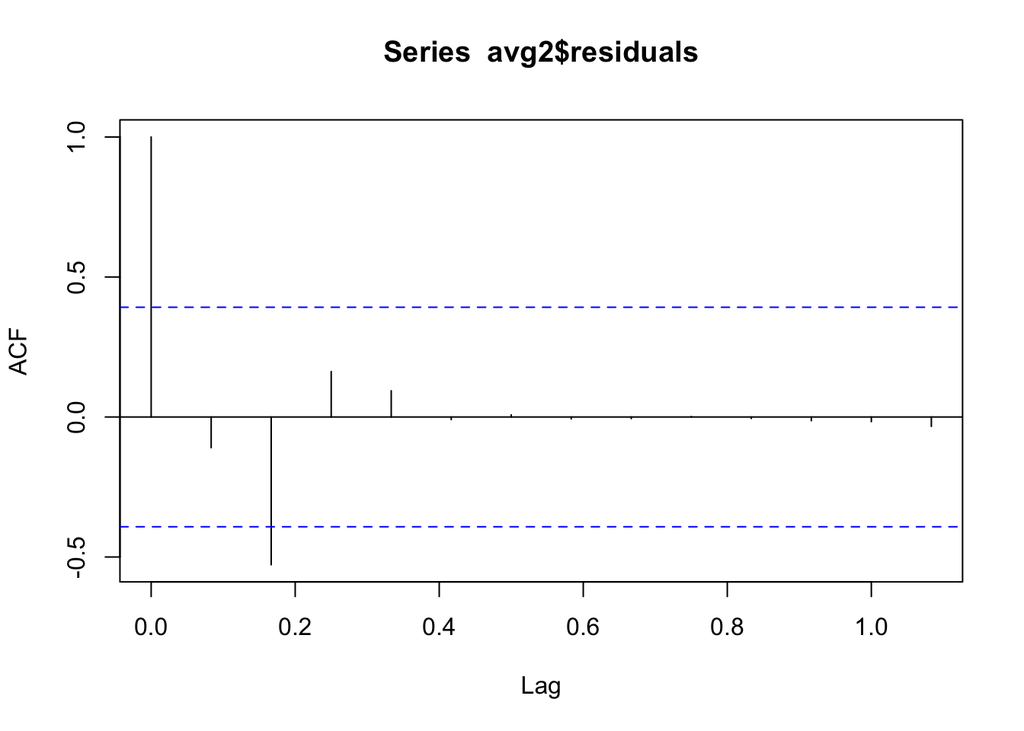

```r
acf(avg2$residuals)
```

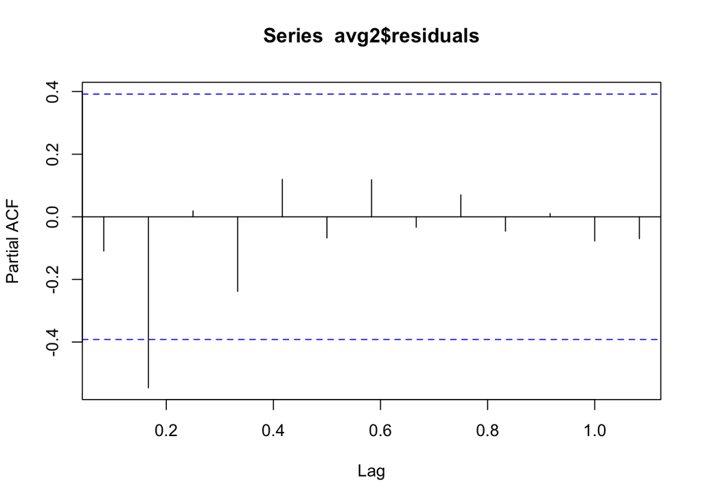

```r
pacf(avg2$residuals)
```

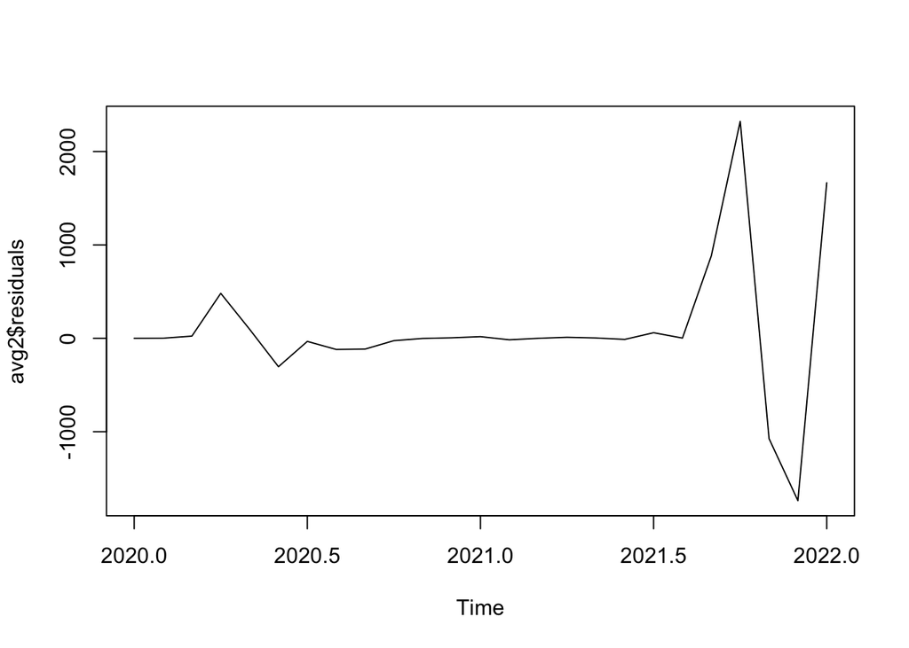

```r
plot(avg2$residuals)
```

Again, both models failed the qqplot test and neither were normally distributed.

# Forecast

Let’s see how our model forecasts future covid values.

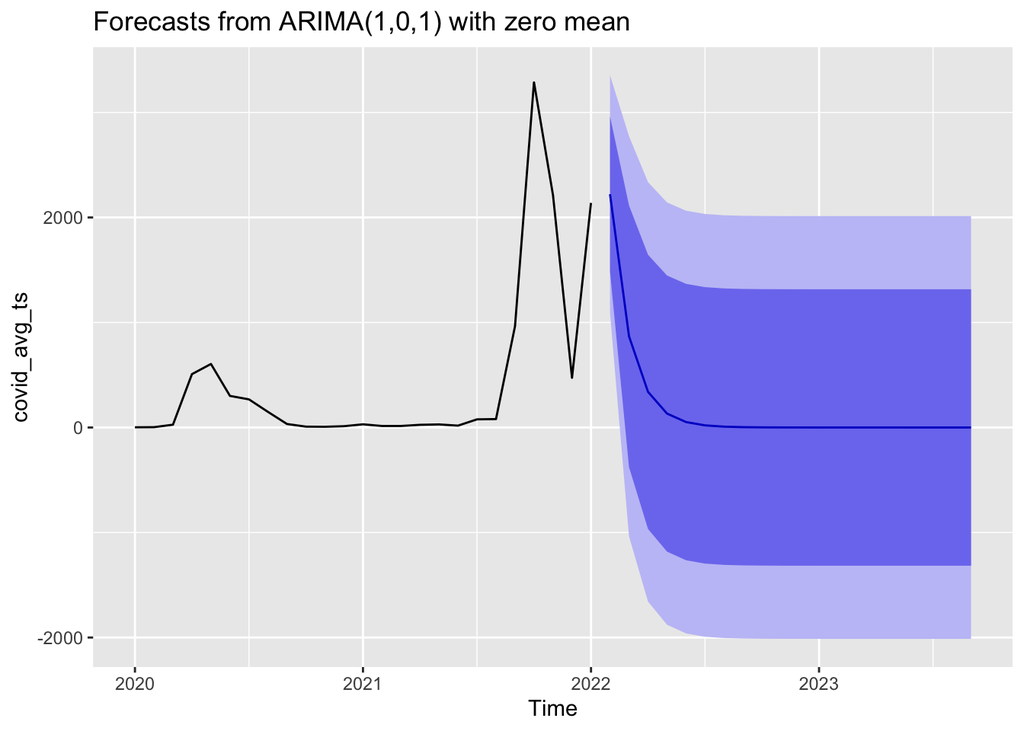

```r
forecast_avg1 = forecast(avg1, 20)
autoplot(forecast_avg1)
```

```r
avg1_test = arima(covid_avg_ts[1:15], order = c(1,0,1), include.mean = F)
f_test = forecast(avg1_test, 11)
covid_avg_ts[15:25] - f_test$mean
```

```
## Time Series:
## Start = 16
## End = 26
## Frequency = 1
##  [1]  -33.263251    3.966406   19.518126   13.216841   75.504811   79.235458
##  [7]  962.963205 3285.398476 2211.617748  473.511249 2138.628393
```

```r
f_test
```

```
##    Point Forecast     Lo 80    Hi 80     Lo 95    Hi 95
## 16    47.61809017 -105.4247 200.6609 -186.4407 281.6769
## 17    21.50026056 -240.4508 283.4513 -379.1193 422.1198
## 18     9.70768048 -269.2767 288.6921 -416.9621 436.3775
## 19     4.38315898 -277.9477 286.7140 -427.4046 436.1709
## 20     1.97906006 -281.0291 284.9873 -430.8446 434.8028
## 21     0.89357441 -282.2525 284.0397 -432.1410 433.9282
## 22     0.40346185 -282.7707 283.5777 -432.6741 433.4810
## 23     0.18216889 -282.9978 283.3621 -432.9042 433.2685
## 24     0.08225191 -283.0988 283.2634 -433.0059 433.1704
## 25     0.03713793 -283.1442 283.2185 -433.0513 433.1256
## 26     0.01676832 -283.1646 283.1982 -433.0718 433.1053
```

```r
avg2_test = arima(covid_avg_ts[1:15], order = c(0,1,0), include.mean = F)
f_test2 = forecast(avg2_test, 11)
covid_avg_ts[15:25] - f_test2$mean
```

```
## Time Series:
## Start = 16
## End = 26
## Frequency = 1
##  [1]    0.000000   11.111828   14.870968    3.245161   63.129032   65.774194
##  [7]  949.011828 3271.225806 2197.345161  459.193548 2124.290323
```

```r
f_test2
```

```
##    Point Forecast     Lo 80    Hi 80      Lo 95     Hi 95
## 16       14.35484 -192.3124 221.0221  -301.7155  330.4252
## 17       14.35484 -277.9168 306.6265  -432.6361  461.3458
## 18       14.35484 -343.6034 372.3131  -533.0950  561.8047
## 19       14.35484 -398.9797 427.6894  -617.7858  646.4955
## 20       14.35484 -447.7672 476.4769  -692.3999  721.1096
## 21       14.35484 -491.8745 520.5842  -759.8562  788.5659
## 22       14.35484 -532.4354 561.1451  -821.8886  850.5983
## 23       14.35484 -570.1885 598.8982  -879.6270  908.3367
## 24       14.35484 -605.6470 634.3567  -933.8561  962.5658
## 25       14.35484 -639.1845 667.8942  -985.1473 1013.8570
## 26       14.35484 -671.0830 699.7927 -1033.9318 1062.6415
```